# Bioinformatics analysis project

Katarzyna Wreczycka 22.09.2022

#### 1. Describe the sequencing reads in the fasta file. This could include some basic statistics about the read lengths and a plot of the read length distribution.

Sequencing reads in the fasta file have varying lengths from 91bp to 65Kbp with an average of 6698bp. Below is a table of basic stastics and a histogram of the read length distribution.

```python
import os, subprocess

input_fasta = "../data/reads.fa"

# Print simple statistics of the input sequences in a tabular table
stdout=os.system("seqkit stats " + input_fasta + " -T | csvtk pretty -t")
```

```
file               format   type   num_seqs   sum_len     min_len   avg_len   max_len
----------------   ------   ----   --------   ---------   -------   -------   -------
../data/reads.fa   FASTA    DNA    28500      190918223   91        6698.9    64968
```

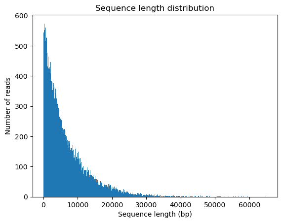

```python
# get length of reads using seqkit
cmd = "seqkit fx2tab -nl " + input_fasta + " | awk '{print $2}'"
cmd_out=subprocess.Popen(cmd,stdout=subprocess.PIPE, shell=True)
out, err = cmd_out.communicate()
read_len = out.splitlines()
read_len = [int(numeric_string) for numeric_string in read_len]

# plot number of reads
import matplotlib.pyplot as plt
x = read_len
num_bins = 500
n, bins, patches = plt.hist(x, num_bins)
plt.xlabel("Sequence length (bp)")
plt.ylabel("Number of reads")
plt.title("Sequence length distribution")
plt.show()
```

#### 2. Identify which two species (among the ten members of the supplied community) produced your reads. Please describe the approach used to determine the species identity and include any figures that show why you are confident in your findings.

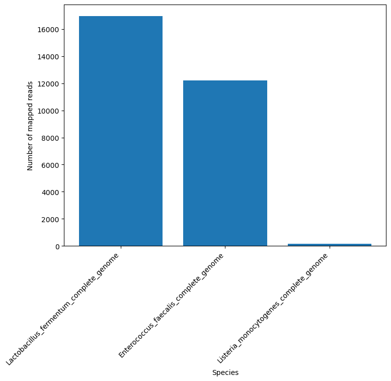

```python
# 1. Plot number of reads per supplied community
import pysam

# read an input bam file
input_bam = "./task3_snakemake/mapped_reads/reads.sorted.bam"
bamfile = pysam.AlignmentFile(input_bam, "rb")

# create a dictionary with keys corresponding to name of species
# and values to number of reads that map to them
top_species = dict()
bam_stats = bamfile.get_index_statistics()
for species in bam_stats:
    if species.mapped != 0 :
        top_species[species.contig] = species.mapped
top_species_sorted = dict(sorted(top_species.items(), key=lambda item: item[1], reverse=True))

# plot a barplot of number of mapped reads per species
fig = plt.figure()
ax = fig.add_axes([0,0,1,1])
ax.bar(top_species_sorted.keys(),
       top_species_sorted.values())
plt.xticks(rotation=45, ha='right')
plt.xlabel("Species")
plt.ylabel("Number of mapped reads")
plt.show()
```

IGV browser screenshot showing reads mapped into the Lactobacilus fermentum genome

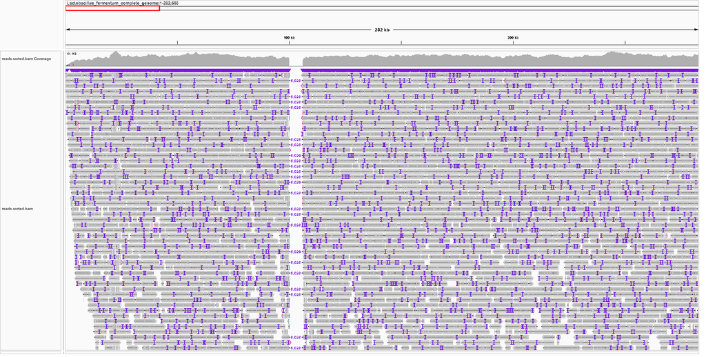

```python
from IPython.display import Image
Image("./IGV_screenshots/IGV_screenshot_Lactobacillus_fermentum.png", width=800)
```

IGV browser screenshot showing reads mapped into the Enterococcus faecalis genome

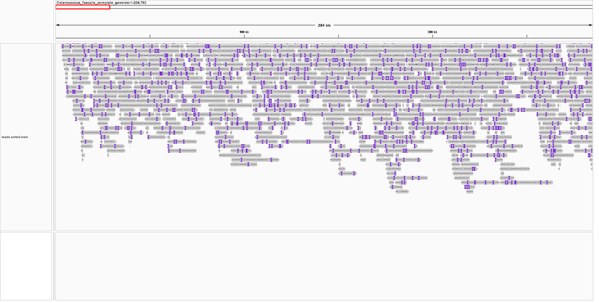

```python
from IPython.display import Image
Image("./IGV_screenshots/IGV_screenshot_enterococcus_faecalis.png", width=800)
```

IGV browser screenshot showing reads mapped into the Listeria monocytogenes genome

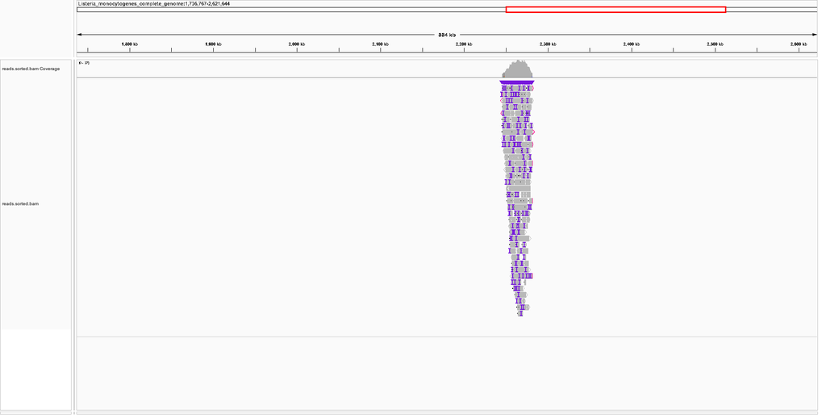

```python
from IPython.display import Image
Image("./IGV_screenshots/IGV_screenshot_Listeria_monocytogenes.png", width=800)
```

#### 3. To make your analysis easier to rerun, write a small Snakemake or Nextflow pipeline that takes the input reads (FASTA) and the 10-species reference (FASTA) and outputs an indexed and sorted BAM file. Please keep this as simple as possible; the file names of the input files and all parameters can be hard coded and don’t have to be variable. Don’t forget to include an example of how to run your pipeline. * If you are not familiar with either snakemake or nextflow you can put the commands into a BASH file instead. *

The results of this task are in the task3_snakemake directory that contains a snakemake file (snakemake.py) and a README file (README.md).

#### 4. Write a small script that accepts a sorted and indexed BAM file as input and counts how many reads in your BAM file map to Enterococcus faecalis. In python, pysam is a very useful library that makes working with BAM files easier. Feel free to use similar packages in R or Perl if you feel more comfortable with any of those. Please don’t use BASH for this task.

The results of this task are in the task4_pysam directory that contains a python script named /task4_pysam.py, and a README file (REDAME.md).

#### Details of the platform and versions of tools:

```python
# Version of system and tools
import os, platform
from importlib.metadata import version

print( platform.system()  +" " + platform.release())
print("python " + platform.python_version())
print("pysam "+" "+version('pysam'))
print("matplotlib "+" "+version('pysam'))
```

```
Linux 5.15.0-41-generic
python 3.10.6
pysam  0.19.1
matplotlib  0.19.1
```